# Teaching Introductory Statistics with *R* and *R* Shiny

Yuanting Lu

Department of Mathematics, Mercer University

100<sup>th</sup> Meeting of MAA-SE (2021)

03/06/2021

- Why *R*
- Calculations
  - Basics
  - Summary Statistics
  - Distributions
  - Inference
- Visualization
- Shiny Apps
- Resources
- It is widely used in academia.
  - Early introduction can flat the learning curve for students who will use it in the future.
  - For students who only use it once in their lifetime, it is a nice opportunity to enrich their academic experience.
- Open-source.
- Powerful data processing and visualization features.

[figure not shown]

[figure not shown]

Left panel: *R* interface (Mac version). Right panel: *RStudio* interface.

## Basic Calculations

Below is an example of confidence interval by hand. The availability of copy-and-past, as well as the quick access to commands’ history (arrow up/down), makes it efficient to do basic calculations in *R*.

```r
0.56 + 1.96 * sqrt(0.56 * (1 - 0.56) / 200)
0.56 - 1.96 * sqrt(0.56 * (1 - 0.56) / 200)
```

The idea of assigning variables can be appealing to students, too.

```r
p = 0.56
n = 200
p + 1.96 * sqrt(p * (1 - p) / n)
p - 1.96 * sqrt(p * (1 - p) / n)
```

[figure not shown]

## Summary statistics

```r
x = c(1.2, 2.4, 3.0, 4.2, 5.9, 6.1, 7.2)
mean(x)
sd(x)
quantile(x, 0.3, type = 2)
```

Loading data file locally can be problematic for beginners due to file path issues. It is easier to

- Use the built-in data sets in *R* or *R* packages.

  ```r
  install.packages("ISLR")
  library(ISLR)
  head(Credit)
  mean(Credit$Balance)
  ```

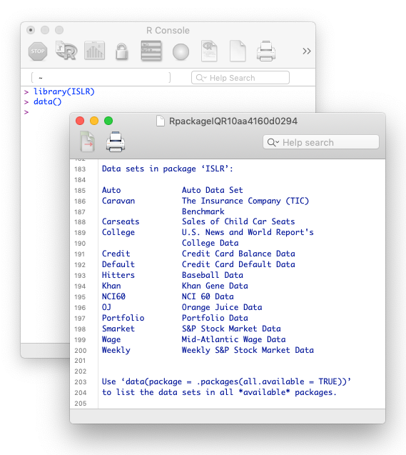

- Ask students to download the data sets online.

```r
departure = read.csv("https://albums.yuanting.lu/sta126/ATL_Departure_Flights_2017.csv")
```

## Distributions

*R* has built-in probability density function (pdf), cumulative distribution function (cdf), and quantile functions for popular distributions.

- Binomial distribution (e.g., n=30 and p=0.8).

  ```r
  dbinom(17, 30, 0.8)
  pbinom(17, 30, 0.8)
  ```

- Normal distribution (e.g., μ=0 and σ=1).

  ```r
  pnorm(-2, 0, 1)
  qnorm(0.975, 0, 1)
  ```

- Student t-distribution (e.g., df=29).

[figure not shown]

[figure not shown]

  ```r
  pt(1.72, 29)
  qt(0.975, 29)
  ```

## Inference

- Categorical variable, e.g., p̂=88/100 against p<sub>0</sub>=0.82.

  ```r
  binom.test(88, 100, conf.level = 0.95)                   # Confidence interval
  binom.test(88, 100, p = 0.82, alternative = "two.sided") # Hypotheses test
  binom.test(88, 100, p = 0.82, alternative = "less")      # Hypotheses test
  binom.test(88, 100, p = 0.82, alternative = "greater")   # Hypotheses test
  ```

- Numeric variable with a given raw data x against μ=2.5.

  ```r
  t.test(x, conf.level = 0.95)                   # Confidence intervals
  t.test(x, mu = 2.5, alternative = "two.sided") # Hypotheses test
  t.test(x, mu = 2.5, alternative = "greater")   # Hypotheses test
  t.test(x, mu = 2.5, alternative = "less")      # Hypotheses test
  ```

[figure not shown]

Bargraphs, boxplots, and histograms can be easily generated by *R*. They are good for

- Lecture illustrations.
- Student project.
  - [Project example](https://albums.yuanting.lu/sta126/Project-graphs): Use *R* to reproduce a graph that you found in a (news) article that looks interesting to you.

Shiny is an *R* package that builds interactive web apps using *R* codes. When deployed on a server, the interactive features allows the apps to facilitate:

- Simulations
  - Example: [Ace a quiz by guessing](https://shiny.yuanting.lu/tfquiz/).
  - Example: [Create the sampling distribution](https://shiny.yuanting.lu/sampling).
- Quick class survey.
  - Example: [Understand the standard deviation](https://shiny.yuanting.lu/StandardDev).
- Data randomization in exams.
  - [Example](https://shiny.yuanting.lu/sta126T4/).

## Resources

- [*SimpleR: Using R for Introductory Statistics*](https://cran.r-project.org/doc/contrib/Verzani-SimpleR.pdf) by John Verzani. 0.4 edition, CUNY, 2002.
- [*An Introduction to Statistical Learning with Applications in R*](https://faculty.marshall.usc.edu/gareth-james/ISL/ISLR%20Seventh%20Printing.pdf) by Gareth James, Daniela Witten, Trevor Hastie, and Robert Tibshirani. Springer, 2017. ISBN 978-1-4614-7138-7 (ebook). The ISLR package that comes with the book has some nice simulated data sets.
- [*Learn Shiny*](https://shiny.rstudio.com/tutorial/), a tutorial from *R* Studio.
- [*Shiny server options*](https://www.yuanting.lu/a74shinyserver), Yuanting Lu’s notes on setting up a Shiny server.
- [*Sample notes for introductory statistics with R*](https://albums.yuanting.lu/sta126/), Yuanting Lu.